# CCP 0 analysis

## 1. Summary

Present bias predicts lower accuracy. The effect on a continuous measure of accuracy is robust, but on the yes/no accuracy is not particularly robust. (I pre-registered both measures.)

Present bias predicts less time spent searching/making credit card decision, although this is only true when we control for total time spent on the survey which was a suppressor.

Notes. The continuous accuracy measure is total costs of the credit card, so higher scores mean choosing cards with higher costs (worse choices). The categorical accuracy is yes/no where yes=1, so higher scores mean more accurate. Beta is coded with Qi’s method, 1 means no present biased, 0 is the most present biased.

## 2. DEEP histograms

### Beta and Delta (Qi’s method)

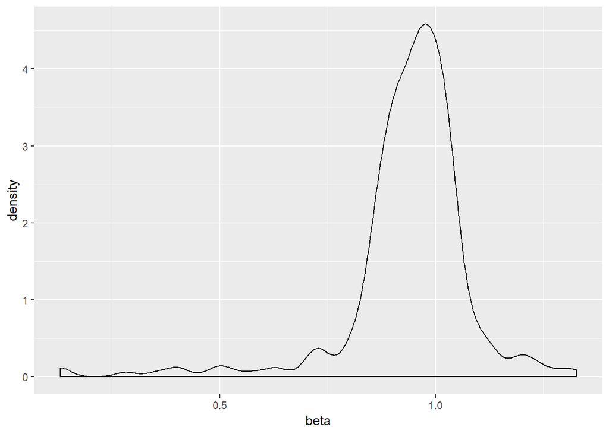

```r
ggplot(ccp0, aes(x = beta)) + geom_density()
```

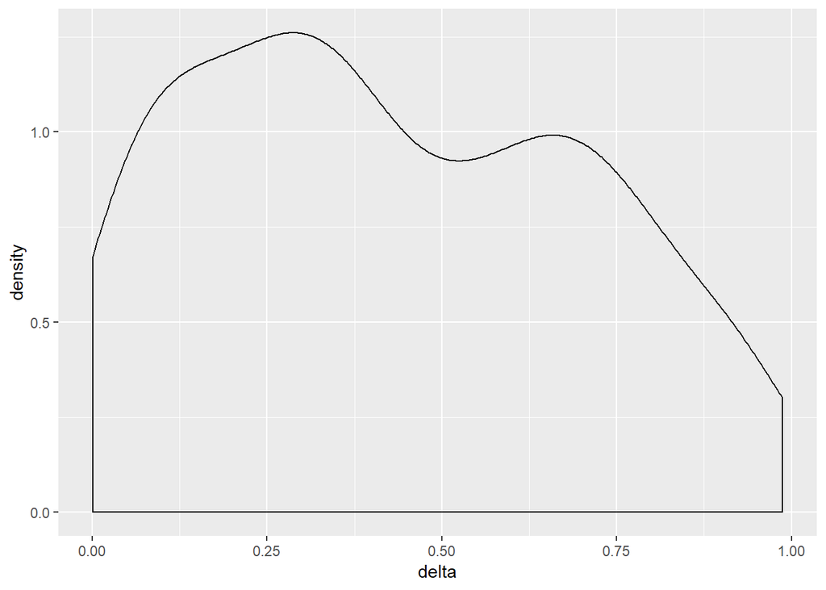

```r
ggplot(ccp0, aes(x = delta)) + geom_density()
```

```r
cor.test(ccp0$beta,ccp0$delta)
```

```
##
##  Pearson's product-moment correlation
##
## data:  ccp0$beta and ccp0$delta
## t = 6.1591, df = 274, p-value = 2.597e-09
## alternative hypothesis: true correlation is not equal to 0
## 95 percent confidence interval:
##  0.2405641 0.4483376
## sample estimates:
##       cor
## 0.3487283
```

## 3. Boxes opened and timing summary statistics

### 3.1. Descriptive Plots and Stats for Accuracy and Time Variables

Time spent on whole survey is in minutes.

Time spent on credit card choice is in seconds.

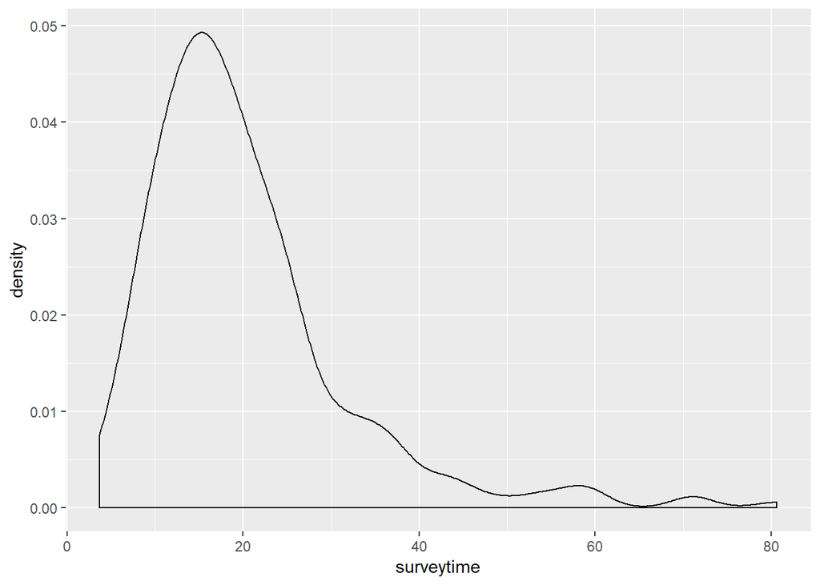

```r
#Time spent on whole survey
ggplot(ccp0, aes(x = surveytime)) + geom_density()
```

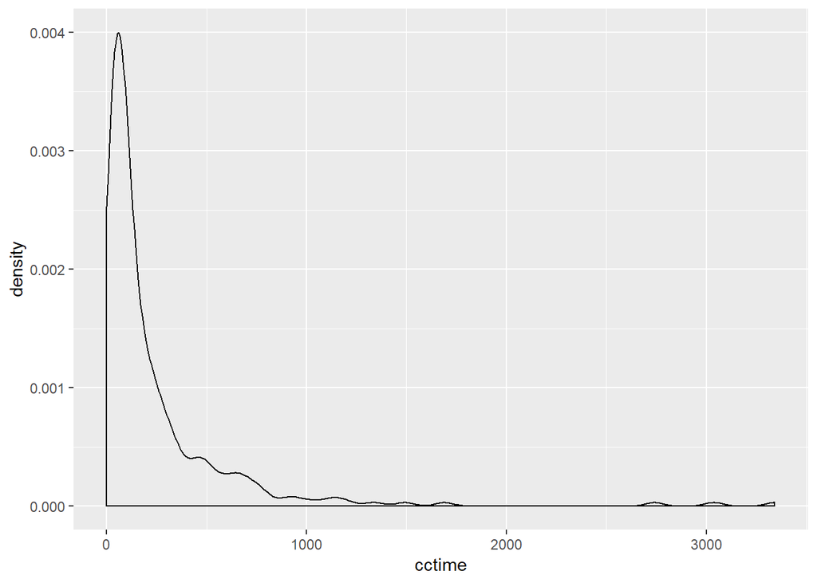

```r
#Time spent searching/choosing credit card
ggplot(ccp0, aes(x = cctime)) + geom_density()
```

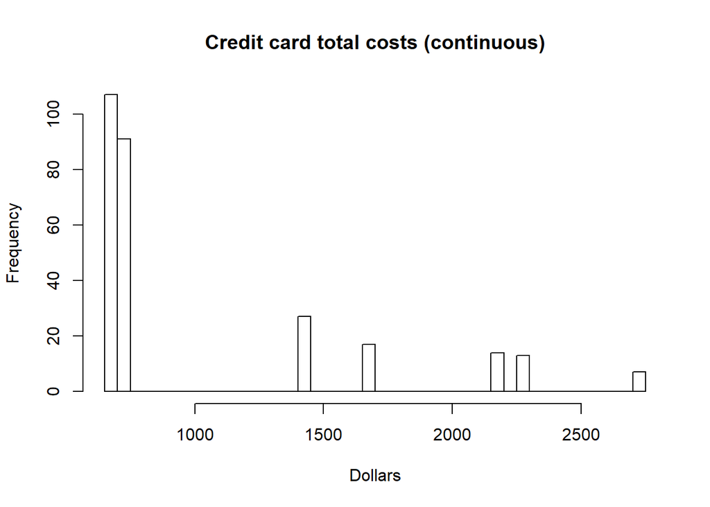

```r
#CC choice Accuracy: Continuous
hist(ccp0$ccCost,main="Credit card total costs (continuous)",xlab="Dollars",breaks=40)
```

```r
#Number of participants choosing card with each level of total costs.
table(ccp0$ccCost)
```

```
##
##  669.76  749.76 1449.84    1665 2174.84 2259.92    2275    2740
##     107      91      27      17      14       4       9       7
```

```r
#CC Choice Accuracy: Binary (yes=1/no=0)
table(ccp0$correct)
```

```
##
##   0   1
## 169 107
```

### 3.2 Skewness of variables

The time variables had large positive skews and log transformations work well (also pre-registered that we would log-transform if skewness was this high).

```r
skewness(ccp0$cctime)
```

```
## [1] 4.529995
```

```r
skewness(ccp0$logtime)
```

```
## [1] -0.2240902
```

```r
skewness(ccp0$restofsurvey)
```

```
## [1] 1.88655
```

```r
skewness(ccp0$logrestofsurvey)
```

```
## [1] -0.4724617
```

## 4. Main Analyses

### 4.1. Present bias predicts choosing cards with higher total costs (continuous measure of inaccuracy, which we pre-registered)

Strongest effect is on this measure

```r
m1a<-lm(ccCost~beta+delta,data=ccp0)
summary(m1a)
```

```
##
## Call:
## lm(formula = ccCost ~ beta + delta, data = ccp0)
##
## Residuals:
##    Min     1Q Median     3Q    Max
## -721.7 -347.1 -265.8  364.1 1757.0
##
## Coefficients:
##             Estimate Std. Error t value Pr(>|t|)
## (Intercept)  1922.18     218.82   8.784  < 2e-16 ***
## beta         -926.53     244.63  -3.788 0.000187 ***
## delta         -36.38     131.46  -0.277 0.782169
## ---
## Signif. codes:  0 '***' 0.001 '**' 0.01 '*' 0.05 '.' 0.1 ' ' 1
##
## Residual standard error: 561.3 on 273 degrees of freedom
## Multiple R-squared:  0.05943,    Adjusted R-squared:  0.05254
## F-statistic: 8.625 on 2 and 273 DF,  p-value: 0.0002331
```

### 4.2. Present bias predicts lower accuracy (binary measure of accuracy, yes/no, which we also pre-registered)

```r
m1b<-glm(correct~beta+delta,data=ccp0,family=binomial)
summary(m1b)
```

```
##
## Call:
## glm(formula = correct ~ beta + delta, family = binomial, data = ccp0)
##
## Deviance Residuals:
##     Min       1Q   Median       3Q      Max
## -1.3267  -1.0094  -0.9368   1.3327   1.6905
##
## Coefficients:
##             Estimate Std. Error z value Pr(>|z|)
## (Intercept)  -2.2363     0.9375  -2.385   0.0171 *
## beta          1.9989     1.0319   1.937   0.0527 .
## delta        -0.2445     0.4811  -0.508   0.6112
## ---
## Signif. codes:  0 '***' 0.001 '**' 0.01 '*' 0.05 '.' 0.1 ' ' 1
##
## (Dispersion parameter for binomial family taken to be 1)
##
##     Null deviance: 368.57  on 275  degrees of freedom
## Residual deviance: 364.30  on 273  degrees of freedom
## AIC: 370.3
##
## Number of Fisher Scoring iterations: 4
```

### 4.3. Present bias and time spent searching/choosing credit card

Effect of beta on time spent choosing is non-significant (1st model below), except when you control for total time spent on survey (2nd model below).

```r
m2<-lm(logtime~beta+delta,data=ccp0)
summary(m2)
```

```
##
## Call:
## lm(formula = logtime ~ beta + delta, data = ccp0)
##
## Residuals:
##      Min       1Q   Median       3Q      Max
## -2.09227 -0.34979  0.00627  0.37685  1.47614
##
## Coefficients:
##             Estimate Std. Error t value Pr(>|t|)
## (Intercept)   1.8429     0.2215   8.321 4.22e-15 ***
## beta          0.2743     0.2476   1.108    0.269
## delta        -0.1476     0.1331  -1.110    0.268
## ---
## Signif. codes:  0 '***' 0.001 '**' 0.01 '*' 0.05 '.' 0.1 ' ' 1
##
## Residual standard error: 0.5681 on 273 degrees of freedom
## Multiple R-squared:  0.006632,   Adjusted R-squared:  -0.0006454
## F-statistic: 0.9113 on 2 and 273 DF,  p-value: 0.4032
```

```r
#We do get an effect of present bias on less time spent making credit card choices when we control for total time spent on survey (because present-biased people spend more time on the survey overall, which suppressed the effect on credit card search time)

m2a<-lm(logtime~beta+delta+logrestofsurvey,data=ccp0)
summary(m2a)
```

```
##
## Call:
## lm(formula = logtime ~ beta + delta + logrestofsurvey, data = ccp0)
##
## Residuals:
##      Min       1Q   Median       3Q      Max
## -1.51568 -0.23984  0.05106  0.29502  0.86546
##
## Coefficients:
##                 Estimate Std. Error t value Pr(>|t|)
## (Intercept)     -0.22629    0.21185  -1.068   0.2864
## beta             0.44236    0.18237   2.426   0.0159 *
## delta           -0.03480    0.09810  -0.355   0.7230
## logrestofsurvey  1.52615    0.09996  15.268   <2e-16 ***
## ---
## Signif. codes:  0 '***' 0.001 '**' 0.01 '*' 0.05 '.' 0.1 ' ' 1
##
## Residual standard error: 0.4177 on 272 degrees of freedom
## Multiple R-squared:  0.4651, Adjusted R-squared:  0.4592
## F-statistic: 78.83 on 3 and 272 DF,  p-value: < 2.2e-16
```

### 4.4. We get a significant indirect effect (though only when we control for time spent on rest of survey).

(This is controlling for total time spent on survey. If we don’t control for total time spent on survey, there is nothing close to an indirect effect.)

Mediation model (ACME is the indirect effect). This was pre-registered as a “secondary analysis”.

```r
a <- lm(logtime ~ beta+delta+logrestofsurvey, data=ccp0)
b <- lm(ccCost ~ beta+delta + logtime+logrestofsurvey, data=ccp0)

# Estimation via quasi-Bayesian approximation
contcont <- mediate(a, b, sims=5000, treat="beta", mediator="logtime")
summary(contcont)
```

```
##
## Causal Mediation Analysis
##
## Quasi-Bayesian Confidence Intervals
##
##                 Estimate 95% CI Lower 95% CI Upper p-value
## ACME           -1.88e+02    -3.67e+02       -36.69  0.0136 *
## ADE            -7.84e+02    -1.26e+03      -333.77  0.0004 ***
## Total Effect   -9.72e+02    -1.47e+03      -501.88  <2e-16 ***
## Prop. Mediated  1.89e-01     4.24e-02         0.42  0.0136 *
## ---
## Signif. codes:  0 '***' 0.001 '**' 0.01 '*' 0.05 '.' 0.1 ' ' 1
##
## Sample Size Used: 276
##
##
## Simulations: 5000
```

## 5. Pre-registered robustness tests

### 5.1 Control for self-reported credit score (nothing changes)

```r
m1ac<-lm(ccCost~beta+delta+Cscore,data=ccp0)
summary(m1ac)
```

```
##
## Call:
## lm(formula = ccCost ~ beta + delta + Cscore, data = ccp0)
##
## Residuals:
##    Min     1Q Median     3Q    Max
## -729.7 -349.9 -262.9  355.0 1746.0
##
## Coefficients:
##             Estimate Std. Error t value Pr(>|t|)
## (Intercept) 1934.008    220.226   8.782  < 2e-16 ***
## beta        -924.276    244.984  -3.773 0.000198 ***
## delta        -33.595    131.732  -0.255 0.798898
## Cscore        -3.840      7.198  -0.533 0.594152
## ---
## Signif. codes:  0 '***' 0.001 '**' 0.01 '*' 0.05 '.' 0.1 ' ' 1
##
## Residual standard error: 562 on 272 degrees of freedom
## Multiple R-squared:  0.06042,    Adjusted R-squared:  0.05005
## F-statistic:  5.83 on 3 and 272 DF,  p-value: 0.0007128
```

```r
m1bc<-glm(correct~beta+delta+Cscore,data=ccp0,family=binomial)
summary(m1bc)
```

```
##
## Call:
## glm(formula = correct ~ beta + delta + Cscore, family = binomial,
##     data = ccp0)
##
## Deviance Residuals:
##     Min       1Q   Median       3Q      Max
## -1.2854  -1.0139  -0.9238   1.3264   1.6914
##
## Coefficients:
##             Estimate Std. Error z value Pr(>|z|)
## (Intercept) -2.18975    0.93997  -2.330   0.0198 *
## beta         2.00526    1.03055   1.946   0.0517 .
## delta       -0.23406    0.48140  -0.486   0.6268
## Cscore      -0.01461    0.02829  -0.516   0.6057
## ---
## Signif. codes:  0 '***' 0.001 '**' 0.01 '*' 0.05 '.' 0.1 ' ' 1
##
## (Dispersion parameter for binomial family taken to be 1)
##
##     Null deviance: 368.57  on 275  degrees of freedom
## Residual deviance: 364.02  on 272  degrees of freedom
## AIC: 372.02
##
## Number of Fisher Scoring iterations: 4
```

```r
m2c<-lm(logtime~beta+delta+Cscore+logrestofsurvey,data=ccp0)
summary(m2c)
```

```
##
## Call:
## lm(formula = logtime ~ beta + delta + Cscore + logrestofsurvey,
##     data = ccp0)
##
## Residuals:
##      Min       1Q   Median       3Q      Max
## -1.51047 -0.24302  0.05207  0.29339  0.86348
##
## Coefficients:
##                  Estimate Std. Error t value Pr(>|t|)
## (Intercept)     -0.209540   0.213296  -0.982   0.3268
## beta             0.437612   0.182644   2.396   0.0173 *
## delta           -0.039332   0.098384  -0.400   0.6896
## Cscore           0.004045   0.005585   0.724   0.4696
## logrestofsurvey  1.504603   0.104376  14.415   <2e-16 ***
## ---
## Signif. codes:  0 '***' 0.001 '**' 0.01 '*' 0.05 '.' 0.1 ' ' 1
##
## Residual standard error: 0.4181 on 271 degrees of freedom
## Multiple R-squared:  0.4661, Adjusted R-squared:  0.4582
## F-statistic: 59.15 on 4 and 271 DF,  p-value: < 2.2e-16
```

### 5.2 Exclude people who don’t own a credit card.

Effects get slightly stronger. Yes/no accuracy goes from p=.052 to p=.02

```r
own<-ccp0[(ccp0$Q131==1),]


m1ae<-lm(ccCost~beta+delta,data=own)
summary(m1ae)
```

```
##
## Call:
## lm(formula = ccCost ~ beta + delta, data = own)
##
## Residuals:
##    Min     1Q Median     3Q    Max
## -750.5 -352.4 -277.7  376.7 1768.7
##
## Coefficients:
##             Estimate Std. Error t value Pr(>|t|)
## (Intercept)  1991.53     241.28   8.254  1.3e-14 ***
## beta        -1030.68     273.71  -3.766 0.000212 ***
## delta          61.76     148.88   0.415 0.678656
## ---
## Signif. codes:  0 '***' 0.001 '**' 0.01 '*' 0.05 '.' 0.1 ' ' 1
##
## Residual standard error: 581 on 225 degrees of freedom
## Multiple R-squared:  0.06365,    Adjusted R-squared:  0.05533
## F-statistic: 7.648 on 2 and 225 DF,  p-value: 0.0006118
```

```r
m1be<-glm(correct~beta+delta,data=own,family=binomial)
summary(m1be)
```

```
##
## Call:
## glm(formula = correct ~ beta + delta, family = binomial, data = own)
##
## Deviance Residuals:
##     Min       1Q   Median       3Q      Max
## -1.3317  -1.0175  -0.9086   1.3052   1.7860
##
## Coefficients:
##             Estimate Std. Error z value Pr(>|z|)
## (Intercept)  -2.8287     1.0952  -2.583   0.0098 **
## beta          2.8369     1.2192   2.327   0.0200 *
## delta        -0.6025     0.5314  -1.134   0.2569
## ---
## Signif. codes:  0 '***' 0.001 '**' 0.01 '*' 0.05 '.' 0.1 ' ' 1
##
## (Dispersion parameter for binomial family taken to be 1)
##
##     Null deviance: 305.89  on 227  degrees of freedom
## Residual deviance: 299.27  on 225  degrees of freedom
## AIC: 305.27
##
## Number of Fisher Scoring iterations: 4
```

```r
m2e<-lm(logtime~beta+delta+logrestofsurvey,data=own)
summary(m2e)
```

```
##
## Call:
## lm(formula = logtime ~ beta + delta + logrestofsurvey, data = own)
##
## Residuals:
##      Min       1Q   Median       3Q      Max
## -1.53128 -0.24502  0.05121  0.31100  0.85529
##
## Coefficients:
##                 Estimate Std. Error t value Pr(>|t|)
## (Intercept)      -0.2309     0.2347  -0.984  0.32628
## beta              0.5378     0.2028   2.652  0.00857 **
## delta            -0.1006     0.1108  -0.908  0.36488
## logrestofsurvey   1.4682     0.1152  12.742  < 2e-16 ***
## ---
## Signif. codes:  0 '***' 0.001 '**' 0.01 '*' 0.05 '.' 0.1 ' ' 1
##
## Residual standard error: 0.4302 on 224 degrees of freedom
## Multiple R-squared:  0.4308, Adjusted R-squared:  0.4232
## F-statistic: 56.51 on 3 and 224 DF,  p-value: < 2.2e-16
```

### 5.3 Exclude search time outliers.

Accuracy effects are unchanged. Search time effect goes away when we exclude the outliers who spent more than 5 min on credit card choice (goes away even when controlling for total survey time).

```r
exc<-ccp0[(ccp0$cctime<300),]

m1ad<-lm(ccCost~beta+delta,data=exc)
summary(m1ad)
```

```
##
## Call:
## lm(formula = ccCost ~ beta + delta, data = exc)
##
## Residuals:
##    Min     1Q Median     3Q    Max
## -775.4 -403.7 -313.0  380.8 1696.5
##
## Coefficients:
##             Estimate Std. Error t value Pr(>|t|)
## (Intercept)  1969.71     253.60   7.767  3.5e-13 ***
## beta         -914.54     281.83  -3.245  0.00137 **
## delta         -32.28     155.19  -0.208  0.83543
## ---
## Signif. codes:  0 '***' 0.001 '**' 0.01 '*' 0.05 '.' 0.1 ' ' 1
##
## Residual standard error: 593.5 on 210 degrees of freedom
## Multiple R-squared:  0.05553,    Adjusted R-squared:  0.04654
## F-statistic: 6.174 on 2 and 210 DF,  p-value: 0.00248
```

```r
m1bd<-glm(correct~beta+delta,data=exc,family=binomial)
summary(m1bd)
```

```
##
## Call:
## glm(formula = correct ~ beta + delta, family = binomial, data = exc)
##
## Deviance Residuals:
##     Min       1Q   Median       3Q      Max
## -1.3547  -0.9785  -0.9029   1.3494   1.7318
##
## Coefficients:
##             Estimate Std. Error z value Pr(>|z|)
## (Intercept)  -2.3763     1.0333  -2.300   0.0215 *
## beta          2.2051     1.1295   1.952   0.0509 .
## delta        -0.4890     0.5414  -0.903   0.3664
## ---
## Signif. codes:  0 '***' 0.001 '**' 0.01 '*' 0.05 '.' 0.1 ' ' 1
##
## (Dispersion parameter for binomial family taken to be 1)
##
##     Null deviance: 281.95  on 212  degrees of freedom
## Residual deviance: 277.60  on 210  degrees of freedom
## AIC: 283.6
##
## Number of Fisher Scoring iterations: 4
```

```r
m2d<-lm(cctime~beta+delta+logrestofsurvey,data=exc)
summary(m2d)
```

```
##
## Call:
## lm(formula = cctime ~ beta + delta + logrestofsurvey, data = exc)
##
## Residuals:
##     Min      1Q  Median      3Q     Max
## -129.28  -42.15   -9.11   27.00  175.95
##
## Coefficients:
##                 Estimate Std. Error t value Pr(>|t|)
## (Intercept)       -91.99      36.79  -2.501   0.0132 *
## beta               33.33      31.05   1.074   0.2842
## delta             -23.27      17.13  -1.358   0.1759
## logrestofsurvey   143.48      19.18   7.479 2.03e-12 ***
## ---
## Signif. codes:  0 '***' 0.001 '**' 0.01 '*' 0.05 '.' 0.1 ' ' 1
##
## Residual standard error: 65.33 on 209 degrees of freedom
## Multiple R-squared:  0.2221, Adjusted R-squared:  0.2109
## F-statistic: 19.89 on 3 and 209 DF,  p-value: 2.215e-11
```

### 5.4 Controlling for all of the key covariates we measured (credit score, financial literacy, numeracy, total time spent on rest of survey, income)

Only the effect on continuous credit card costs remains.

For the yes/no accuracy DV, it seems to be financial literacy and numeracy that caused the effect to go away; if you remove both those covariates, the effect reappears. If you add just one of those back in (either one), the effect goes away.

```r
m1af<-lm(ccCost~beta+delta+Cscore+FL_tot+Numeracy+logrestofsurvey+hh_income,data=ccp0)
summary(m1af)
```

```
##
## Call:
## lm(formula = ccCost ~ beta + delta + Cscore + FL_tot + Numeracy +
##     logrestofsurvey + hh_income, data = ccp0)
##
## Residuals:
##      Min       1Q   Median       3Q      Max
## -1065.64  -266.15   -72.71   175.11  1415.53
##
## Coefficients:
##                   Estimate Std. Error t value Pr(>|t|)
## (Intercept)      2.406e+03  2.505e+02   9.601  < 2e-16 ***
## beta            -4.738e+02  2.191e+02  -2.162   0.0315 *
## delta           -1.732e+02  1.147e+02  -1.510   0.1322
## Cscore           4.639e+00  6.449e+00   0.719   0.4726
## FL_tot          -8.301e+01  1.225e+01  -6.774 8.02e-11 ***
## Numeracy        -7.361e+01  3.418e+01  -2.153   0.0322 *
## logrestofsurvey -1.474e+02  1.246e+02  -1.183   0.2380
## hh_income        1.947e-03  8.448e-04   2.305   0.0219 *
## ---
## Signif. codes:  0 '***' 0.001 '**' 0.01 '*' 0.05 '.' 0.1 ' ' 1
##
## Residual standard error: 481.4 on 266 degrees of freedom
##   (2 observations deleted due to missingness)
## Multiple R-squared:  0.3218, Adjusted R-squared:  0.3039
## F-statistic: 18.03 on 7 and 266 DF,  p-value: < 2.2e-16
```

```r
m1bf<-glm(correct~beta+delta+Cscore+FL_tot+Numeracy+logrestofsurvey+hh_income,data=ccp0,family=binomial)
summary(m1bf)
```

```
##
## Call:
## glm(formula = correct ~ beta + delta + Cscore + FL_tot + Numeracy +
##     logrestofsurvey + hh_income, family = binomial, data = ccp0)
##
## Deviance Residuals:
##     Min       1Q   Median       3Q      Max
## -1.5823  -0.9408  -0.5306   1.0618   2.4051
##
## Coefficients:
##                   Estimate Std. Error z value Pr(>|z|)
## (Intercept)     -3.479e+00  1.328e+00  -2.620   0.0088 **
## beta             9.889e-01  1.135e+00   0.871   0.3835
## delta            6.186e-02  5.282e-01   0.117   0.9068
## Cscore          -3.547e-02  3.320e-02  -1.068   0.2854
## FL_tot           3.351e-01  6.801e-02   4.927 8.36e-07 ***
## Numeracy        -6.311e-02  1.670e-01  -0.378   0.7054
## logrestofsurvey -7.632e-02  6.151e-01  -0.124   0.9013
## hh_income       -5.453e-06  3.825e-06  -1.426   0.1540
## ---
## Signif. codes:  0 '***' 0.001 '**' 0.01 '*' 0.05 '.' 0.1 ' ' 1
##
## (Dispersion parameter for binomial family taken to be 1)
##
##     Null deviance: 366.6  on 273  degrees of freedom
## Residual deviance: 320.8  on 266  degrees of freedom
##   (2 observations deleted due to missingness)
## AIC: 336.8
##
## Number of Fisher Scoring iterations: 4
```

```r
m2cf<-lm(logtime~beta+delta+Cscore+FL_tot+Numeracy+logrestofsurvey+hh_income,data=ccp0)
summary(m2cf)
```

```
##
## Call:
## lm(formula = logtime ~ beta + delta + Cscore + FL_tot + Numeracy +
##     logrestofsurvey + hh_income, data = ccp0)
##
## Residuals:
##      Min       1Q   Median       3Q      Max
## -1.20324 -0.22019  0.01228  0.24774  0.93948
##
## Coefficients:
##                   Estimate Std. Error t value Pr(>|t|)
## (Intercept)     -2.270e-01  1.923e-01  -1.181    0.239
## beta             2.597e-02  1.682e-01   0.154    0.877
## delta            2.665e-02  8.805e-02   0.303    0.762
## Cscore           3.452e-03  4.950e-03   0.697    0.486
## FL_tot           4.460e-02  9.406e-03   4.742 3.45e-06 ***
## Numeracy         1.100e-01  2.624e-02   4.192 3.77e-05 ***
## logrestofsurvey  1.335e+00  9.565e-02  13.952  < 2e-16 ***
## hh_income        1.617e-07  6.485e-07   0.249    0.803
## ---
## Signif. codes:  0 '***' 0.001 '**' 0.01 '*' 0.05 '.' 0.1 ' ' 1
##
## Residual standard error: 0.3695 on 266 degrees of freedom
##   (2 observations deleted due to missingness)
## Multiple R-squared:  0.5905, Adjusted R-squared:  0.5798
## F-statistic:  54.8 on 7 and 266 DF,  p-value: < 2.2e-16
```

```r
#financial literacy, self-reported credit scores, income category, numeracy, and time spent on the rest of the survey (not including credit card choice task)
```

## 6. Other tests (not pre-registered)

Excluding people who calculated costs with Excel or Calculator

Effects get weaker. Only the continuous costs measure remains significant.

```r
nocalc<-ccp0[(ccp0$calculator==0),]
nodevice<-nocalc[(nocalc$otherdev==0),]
noexcel<-nodevice[(nodevice$spreadsheet==0),]

m1ad<-lm(ccCost~beta+delta,data=noexcel)
summary(m1ad)
```

```
##
## Call:
## lm(formula = ccCost ~ beta + delta, data = noexcel)
##
## Residuals:
##    Min     1Q Median     3Q    Max
## -721.0 -384.1 -282.7  397.8 1629.6
##
## Coefficients:
##             Estimate Std. Error t value Pr(>|t|)
## (Intercept)   1865.5      273.9   6.810 1.19e-10 ***
## beta          -794.9      303.6  -2.618  0.00954 **
## delta         -112.5      154.2  -0.729  0.46661
## ---
## Signif. codes:  0 '***' 0.001 '**' 0.01 '*' 0.05 '.' 0.1 ' ' 1
##
## Residual standard error: 565.9 on 194 degrees of freedom
## Multiple R-squared:  0.04894,    Adjusted R-squared:  0.03914
## F-statistic: 4.992 on 2 and 194 DF,  p-value: 0.007691
```

```r
m1bd<-glm(correct~beta+delta,data=noexcel,family=binomial)
summary(m1bd)
```

```
##
## Call:
## glm(formula = correct ~ beta + delta, family = binomial, data = noexcel)
##
## Deviance Residuals:
##    Min      1Q  Median      3Q     Max
## -1.321  -1.017  -0.948   1.326   1.605
##
## Coefficients:
##             Estimate Std. Error z value Pr(>|z|)
## (Intercept)  -2.1555     1.1252  -1.916   0.0554 .
## beta          1.9220     1.2286   1.564   0.1177
## delta        -0.2131     0.5573  -0.382   0.7021
## ---
## Signif. codes:  0 '***' 0.001 '**' 0.01 '*' 0.05 '.' 0.1 ' ' 1
##
## (Dispersion parameter for binomial family taken to be 1)
##
##     Null deviance: 264.50  on 196  degrees of freedom
## Residual deviance: 261.78  on 194  degrees of freedom
## AIC: 267.78
##
## Number of Fisher Scoring iterations: 4
```

```r
m2d<-lm(logtime~beta+delta+logrestofsurvey,data=noexcel)
summary(m2d)
```

```
##
## Call:
## lm(formula = logtime ~ beta + delta + logrestofsurvey, data = noexcel)
##
## Residuals:
##     Min      1Q  Median      3Q     Max
## -1.0186 -0.1860  0.0476  0.2047  0.7574
##
## Coefficients:
##                  Estimate Std. Error t value Pr(>|t|)
## (Intercept)     0.5319927  0.2223662   2.392   0.0177 *
## beta            0.0009176  0.1877990   0.005   0.9961
## delta           0.0515166  0.0951976   0.541   0.5890
## logrestofsurvey 1.1544905  0.1019654  11.322   <2e-16 ***
## ---
## Signif. codes:  0 '***' 0.001 '**' 0.01 '*' 0.05 '.' 0.1 ' ' 1
##
## Residual standard error: 0.3476 on 193 degrees of freedom
## Multiple R-squared:  0.4046, Adjusted R-squared:  0.3953
## F-statistic: 43.72 on 3 and 193 DF,  p-value: < 2.2e-16
```